# Notebook

**Einführung ins Maschinelle Lernen**

Dr. Matthias Hölzl

[figure not shown]

### Was ist Maschinelles Lernen (ML)?

Entwicklung von Systemen, die aus Daten lernen können

### Warum?

- Viele reale Probleme sind zu komplex, um sie mit traditionellen Programmiertechniken zu lösen.
- Die Funktionsweise eines Programms kann verbessert/angepasst werden, indem wir ihm mehr Daten geben.

### Wie funktioniert das?

- Wir erstellen ein **Modell**
  - Programm, das mehrere ähnliche Probleme lösen kann
- Wir **trainieren** das Modell
  - Indem wir ihm Daten zeigen, lernt es unser konkretes Problem zu lösen
- Wir **evaluieren** das Modell
  - Wir testen, wie gut es unser konkretes Problem löst

### Beispiel: Preis eines Pizzas

- Preis einer Pizza bestimmt durch
  - Grundpreis
  - Anzahl der Beläge (jeder Belag kostet gleich viel)
- Ist das ein Problem, für das sich ML anbietet?

### Programm zur Berechnung des Pizza-Preises

```python
def calculate_pizza_price(num_toppings):
    base_price = 5.00
    price_per_topping = 1.50
    total_price = base_price + (price_per_topping * num_toppings)
    return total_price
```

```python
calculate_pizza_price(3)
```

```
9.5
```

- Was ist, wenn wir das Programm für verschiedene Pizzerien verwenden wollen?
  - Unterschiedliche Grundpreise
  - Unterschiedliche Preise pro Belag
- Wir können ein Programm schreiben, das für beliebige Preise funktioniert

```python
class PizzaPriceCalculator:
    def __init__(self, base_price, price_per_topping):
        self.base_price = base_price
        self.price_per_topping = price_per_topping

    def calculate_price(self, num_toppings):
        total_price = self.base_price + (self.price_per_topping * num_toppings)
        return total_price
```

```python
luigis_pizza_calculator = PizzaPriceCalculator(base_price=6.00, price_per_topping=1.25)
```

```python
luigis_pizza_calculator.calculate_price(3)
```

```
9.75
```

```python
marios_pizza_calculator = PizzaPriceCalculator(base_price=4.50, price_per_topping=1.75)
```

```python
marios_pizza_calculator.calculate_price(3)
```

```
9.75
```

- Unser `PizzaCalculator` kann "verschiedene Probleme" lösen
- Aber er kann nicht "lernen"

### Beispiel: Catering-Service

- Wir wollen einen Catering-Service starten
- Wie viel sollen wir für ein Event verlangen?
- Vermutung: Konkurrenzpreise bestehen aus
  - Grundpreis
  - Preis pro Person
- Aber wir bekommen von der Konkurrenz nur Angebote für komplette Events, nicht die Komponenten dahinter
- Wie können wir vorgehen?
  - Ist das ein Problem, für das sich ML anbietet?

### Vorgehensweise

- Wir holen uns von Konkurrenten Angebote für Events mit verschiedenen Personenzahlen
- Daraus versuchen wir, den Grundpreis und den Preis pro Person zu schätzen
  - Werte ausprobieren
  - Mathematisch: Lineare Regression
  - Graphisch: Gerade durch Punktewolke legen

### Daten von Anbieter A

| Anzahl Personen | Angebotspreis |
| --- | --- |
| 10 | 400 € |
| 20 | 700 € |
| 30 | 1000 € |

### Visualisierung der Preise

```python
import matplotlib.pyplot as plt
```

```python
# Data from Provider A
num_people = [10, 20, 30]
offered_prices = [400, 700, 1000]
```

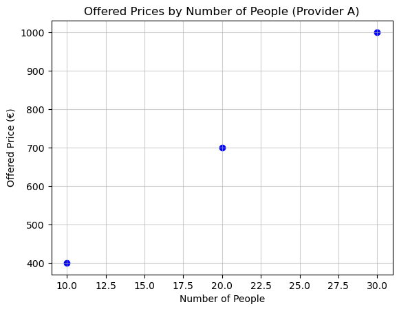

```python
plt.scatter(num_people, offered_prices, color="blue")
plt.title("Offered Prices by Number of People (Provider A)")
plt.xlabel("Number of People")
plt.ylabel("Offered Price (€)")
plt.grid(True, alpha=0.6)
plt.show()
```

```python
class CateringPriceModel:
    def __init__(self, base_price, price_per_person):
        self.base_price = base_price
        self.price_per_person = price_per_person

    def predict_price(self, num_people):
        total_price = self.base_price + (self.price_per_person * num_people)
        return total_price
```

### Interaktive Visualisierung des Catering-Preismodells

```python
from ipywidgets import interact, FloatSlider
```

```python
def plot_catering_model(base_price=100.0, price_per_person=30.0):
    x_values = list(range(0, 41))

    model = CateringPriceModel(base_price, price_per_person)
    y_values = [model.predict_price(x) for x in x_values]

    plt.figure(figsize=(10, 6))
    plt.plot(x_values, y_values, "r-", linewidth=2, label="Model Prediction")
    plt.scatter(num_people, offered_prices, s=100, zorder=5, label="Provider A Data")
    plt.title(
        f"Catering Price Model (Base: €{base_price:.2f}, Per Person: €{price_per_person:.2f})"
    )
    plt.xlabel("Number of People")
    plt.ylabel("Price (€)")
    plt.grid(True, alpha=0.6)
    plt.legend()
    plt.xlim(0, 40)
    plt.ylim(0, max(max(y_values), max(offered_prices)) * 1.1)
    plt.show()
```

```python
interact(
    plot_catering_model,
    base_price=FloatSlider(
        min=0, max=500, step=10, value=400, description="Base Price (€)"
    ),
    price_per_person=FloatSlider(
        min=0, max=100, step=5, value=10, description="Price/Person (€)"
    ),
)
```

```
interactive(children=(FloatSlider(value=400.0, description='Base Price (€)', max=500.0, step=10.0), FloatSlide…
```

```
<function __main__.plot_catering_model(base_price=100.0, price_per_person=30.0)>
```

Können wir das Berechnen von `base_price` und `price_per_person` automatisieren?

```python
class CateringPriceModelNaive:
    def __init__(self):
        self.base_price = 0
        self.price_per_person = 0

    def fit(self, num_people, offered_prices):
        n = len(num_people)
        if n < 2:
            raise ValueError(
                "At least two data points are required to train the model."
            )
        if n != len(offered_prices):
            raise ValueError("num_people and offered_prices must have the same length.")
        dy = offered_prices[-1] - offered_prices[0]
        dx = num_people[-1] - num_people[0]
        self.price_per_person = dy / dx
        self.base_price = offered_prices[0] - (self.price_per_person * num_people[0])

    def predict(self, num_people):
        total_price = self.base_price + (self.price_per_person * num_people)
        return total_price
```

### Trainieren des Modells

```python
catering_model_naive = CateringPriceModelNaive()
```

```python
catering_model_naive.fit(num_people, offered_prices)
```

```python
catering_model_naive.base_price, catering_model_naive.price_per_person
```

```
(100.0, 30.0)
```

### Verwenden des trainierten Modells

Für Werte, die das Modell bereits gesehen hat:

```python
catering_model_naive.predict(10)
```

```
400.0
```

Für Werte, die das Modell noch nie gesehen hat:

```python
catering_model_naive.predict(25)
```

```
850.0
```

### Verwenden von Scikit-Learn Modellen

- Unser Modell hat nicht wirklich etwas mit "Catering" zu tun
  - Es lässt sich auf jedes Problem anwenden, bei dem eine lineare Beziehung zwischen Eingabe und Ausgabe besteht
- Die Implementierung ist sehr einfach und nicht sehr robust
  - Es ignoriert beim Training alle Punkte außer den ersten und letzten
  - Es kann nicht mit Daten umgehen, die "Rauschen" enthalten
- Die Bibliothek [Scikit-Learn](https://scikit-learn.org/) bietet viele vorgefertigte Modelle, die wir verwenden können
- Unser Modell nennt man eine **lineare Regression**

```python
!pip install scikit-learn --root-user-action ignore
```

```python
from sklearn.linear_model import LinearRegression
```

```python
sklearn_model = LinearRegression()
```

```python
num_people_reshaped = [[n] for n in num_people]
```

```python
num_people_reshaped
```

```
[[10], [20], [30]]
```

```python
sklearn_model.fit(num_people_reshaped, offered_prices)
```

```
LinearRegression()
```

```python
sklearn_model.intercept_, sklearn_model.coef_
```

```
(np.float64(100.0), array([30.]))
```

### Verwenden des Scikit-Learn Modells

Für Werte, die das Modell bereits gesehen hat:

```python
sklearn_model.predict([[10]])
```

```
array([400.])
```

Für Werte, die das Modell noch nie gesehen hat:

```python
sklearn_model.predict([[25]])
```

```
array([850.])
```

Für mehrere Werte

```python
sklearn_model.predict([[10], [25], [40], [100]])
```

```
array([ 400.,  850., 1300., 3100.])
```

## Programm vs. trainiertes Modell

[figure not shown]

## Programm vs. trainiertes Modell

[figure not shown]

## Programm vs. Modell (Erstellung)

[figure not shown]

## Programm vs. Modell (Erstellung)

[figure not shown]

## Workshop: Fremdenführer

Sie wollen einen Service starten, der Touristen durch Ihre Stadt führt. Um die Preise für Ihre Führungen festzulegen, haben Sie die Preise von Wettbewerbern in der Nähe recherchiert und die folgenden Daten gesammelt:

| Anzahl Personen | Angebotspreis |
| --- | --- |
| 5 | 150 € |
| 10 | 250 € |
| 30 | 650 € |

- Erstellen Sie ein Modell, das den Angebotspreis Ihres Wettbewerbers in Abhängigkeit von der Anzahl der Personen vorhersagt.
- Sagt dieses Modell die bekannten Datenpunkte korrekt voraus?
- Was sind die geschätzten Werte für Grundpreis und Preis pro Person?

```python
# Data from Competitor
num_people_competitor = [5, 10, 30]
offered_prices_competitor = [150, 250, 650]
```

```python
# Prepare the data
num_people_competitor_reshaped = [[n] for n in num_people_competitor]
```

```python
# Create and train the model
sklearn_model_competitor = LinearRegression()
sklearn_model_competitor.fit(num_people_competitor_reshaped, offered_prices_competitor)
```

```
LinearRegression()
```

```python
# Check predictions for known data points
sklearn_model_competitor.predict(num_people_competitor_reshaped)
```

```
array([150., 250., 650.])
```

```python
# Estimate base price and price per person
intercept_competitor = float(sklearn_model_competitor.intercept_)
coef_competitor = float(sklearn_model_competitor.coef_[0])
```

```python
intercept_competitor, coef_competitor
```

```
(50.000000000000114, 19.999999999999993)
```

Angenommen, Ihr Wettbewerber hätte Ihnen stattdessen die folgenden Preise genannt:

| Anzahl Personen | Angebotspreis |
| --- | --- |
| 5 | 150 € |
| 10 | 250 € |
| 30 | 500 € |

Könnten Sie die Preise mit dem gleichen Modell vorhersagen, oder gibt es dabei Probleme?

Versuchen Sie, die Preise mit dem gleichen Modell vorherzusagen. Was fällt Ihnen auf? Können Sie das Problem erklären?

```python
offered_prices_competitor_non_linear = [150, 250, 500]
```

```python
from ipywidgets import interact, FloatSlider
```

```python
def plot_tour_guide_prices(base_price=100.0, price_per_person=30.0):
    """Plot the tour-guide prices with given parameters."""
    # Create x values from 0 to 40
    x_values = list(range(0, 41))

    # Create model and calculate prices
    y_values = [base_price + price_per_person * x for x in x_values]

    # Create the plot
    plt.figure(figsize=(10, 6))

    # Plot the model line
    plt.plot(x_values, y_values, "r-", linewidth=2, label="Model Prediction")

    # Plot the original data points from Provider A
    plt.scatter(
        num_people_competitor,
        offered_prices_competitor_non_linear,
        color="blue",
        s=100,
        zorder=5,
        label="Provider A Data",
    )

    plt.title(
        f"Tour Guide Prices (Base: €{base_price:.2f}, Per Person: €{price_per_person:.2f})"
    )
    plt.xlabel("Number of People")
    plt.ylabel("Price (€)")
    plt.grid(True, alpha=0.6)
    plt.legend()
    plt.xlim(0, 40)
    plt.ylim(0, max(max(y_values), max(offered_prices_competitor_non_linear)) * 1.1)
    plt.show()
```

```python
interact(
    plot_tour_guide_prices,
    base_price=FloatSlider(
        min=0, max=200, step=1, value=100, description="Base Price (€)"
    ),
    price_per_person=FloatSlider(
        min=0, max=100, step=1, value=10, description="Price/Person (€)"
    ),
)
```

```
interactive(children=(FloatSlider(value=100.0, description='Base Price (€)', max=200.0, step=1.0), FloatSlider…
```

```
<function __main__.plot_tour_guide_prices(base_price=100.0, price_per_person=30.0)>
```

```python
# Create and train the model
sklearn_model_competitor_non_linear = LinearRegression()
sklearn_model_competitor_non_linear.fit(
    num_people_competitor_reshaped, offered_prices_competitor_non_linear
)
```

```
LinearRegression()
```

```python
# Check predictions for known data points
sklearn_model_competitor_non_linear.predict(num_people_competitor_reshaped)
```

```
array([164.28571429, 232.14285714, 503.57142857])
```

```python
# Estimate base price and price per person
intercept_competitor_non_linear = float(sklearn_model_competitor_non_linear.intercept_)
coef_competitor_non_linear = float(sklearn_model_competitor_non_linear.coef_[0])
```

```python
intercept_competitor_non_linear, coef_competitor_non_linear
```

```
(96.42857142857144, 13.571428571428571)
```